# Lab - 6 Convolutional Neural Networks

### Muralidhar Madabhushi Balaji and Rick Simon

# 1. Introduction

In this lab, we use a convolutional neural network model to classify a given 2-D autocorrelation image into one of the 10 numeric digits. A huge number of imaging techniques such as non-line of sight imaging, coherent X-ray diffraction imaging, electron microscopy,astronomy and super-resolution optical imaging [1,2] rely on the ability to recover the image of the object from its autocorrelation. The focus in this work is on the non line of sight imaging problem, wherein, the image of an object hidden around a corner needs to be extracted at sub-millimeter resolutions.

### 1.1. Indirect imaging correlography[3]

The hidden object is indirectly illuminated by the light scatterred off of a rough surface (wall) as shown in figure below. The light after scatterring off of the object finds it way to the observable region on the wall, known as virtuial detector. Due to the random nature of the rough surfaces involved, the resulting pattern at the virtual detector will have a granular appearance, also known as a speckle pattern. This pattern is recorded by a camera imaging the wall. By exploiting the properties of this speckle pattern, the autocorrelation of the object can be estimated.

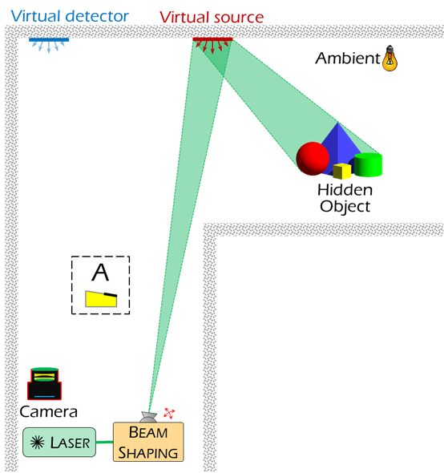

The inability to directly get at the object's image from these speckle patterns is due to the fact that only the intensity of the light is recorded by the camera and the phase information (which is a function of the total path traveled by the light) is absent. Thus, traditionally, a class of algorithms known as phase retrieval algorithms are employed to retrieve the image of the object from its autocorrelation. But, these phase retrieval algorithms require very high fidelity measurements with less noise.

Since the object of interest will be a part of an alphabet or a digit, for eg., on an ID badge, we can try to build a classification algorithm that can detect a digit/alphabet or multiple digits/alphabet using a CNN. In this lab, we only focus on classifying digits given an autocorrelation.

### References:

[1]. Cherukara, Mathew J., Youssef SG Nashed, and Ross J. Harder. "Real-time coherent diffraction inversion using deep generative networks." Scientific reports 8.1 (2018): 16520.

[2] Metzler, Christopher A., et al. "prDeep: Robust phase retrieval with a flexible deep network." arXiv preprint arXiv:1803.00212 (2018).

[3] Viswanath, Aparna, et al. "Indirect Imaging Using Correlography." Computational Optical Sensing and Imaging. Optical Society of America, 2018.

```python
import keras
from keras.models import Sequential
from keras.layers import Reshape
from keras.layers import Dense, Dropout, Activation, Flatten
from keras.layers import Conv2D, MaxPooling2D
from keras.preprocessing.image import ImageDataGenerator
from keras.callbacks import EarlyStopping
from keras.regularizers import l2
from keras.layers import average
from keras.models import Input, Model, model_from_json
import os

keras.__version__
```

```
'2.2.4'
```

```python
import h5py
import numpy as np
from sklearn import metrics as mt
from matplotlib import pyplot as plt
from skimage.io import imshow
import seaborn as sns
%matplotlib inline
```

### 1.2. Training dataset

To train the classifier, we generated the autocorrelation from the MNIST database[1]. To generate these autocorrelations, we zero-padded the images to twice the actual size. From these padded images, we generated the autocorrelations and saved it to a mat-file. The matlab code used to generate these autocorrelations from MNIST dataset is shared in the appendix.

The MNIST images are of size 28 X 28. Our autocorrelations are of size 56 X 56.

Thus, the inputs for the classifier are the autocorrelation images and the outputs are the one-hot encoded labels from MNIST database.

MNIST dataset has 60,000 training examples and 10,000 test examples. And these dataset is pretty uniformly distributed across all the digits. Hence, we decided not to do any further splitting of data.

We have tried two CNN architectures with this dataset which include: 1) A normal CNN and 2) A ResNet with skip connections

We used accuracy as the metric to compare the performance of the networks. The dataset is uniformly distributed across all the in both training and testing dataset. And, we also expect the classifier to classify all the digits with equal accuracy as no one digit is more likely than the other in the scenario mentioned in section-1.

### Reference

[1]. http://yann.lecun.com/exdb/mnist/

```python
arrays = {}
f = h5py.File('MNIST_Autocorrelation.mat')
```

```python
print(list(f.keys()))

for k, v in f.items():
    arrays[k] = np.array(v)
```

```
[u'TestData', u'TestLabels', u'TrainData', u'TrainLabels']
```

```python
X_train = arrays['TrainData']
y_train = arrays['TrainLabels'].squeeze()
X_test = arrays['TestData']
y_test = arrays['TestLabels'].squeeze()

NUM_CLASSES = 10
```

The autocorrelations were saved as 8 bit integers and hence go from 0-255. These are normalized to go from -0.5 to 0.5

```python
# https://bic-berkeley.github.io/psych-214-fall-2016/numpy_transpose.html
#X_train = X_train[:,:,0:NUM_TRAIN_IMAGES]
X_train = X_train.transpose(2, 0, 1)
X_train = X_train/255.0 - 0.5
img_wh = 56;
# NEW: Let's start by fixing the sizes
X_train = np.expand_dims(X_train.reshape((-1,img_wh,img_wh)), axis=3)
print(X_train.shape)
```

```
(60000, 56, 56, 1)
```

```python
# https://bic-berkeley.github.io/psych-214-fall-2016/numpy_transpose.html
X_test = X_test.transpose(2, 0, 1)
X_test = X_test/255.0 - 0.5
img_wh = 56;
# NEW: Let's start by fixing the sizes
X_test = np.expand_dims(X_test.reshape((-1,img_wh,img_wh)), axis=3)
print(X_test.shape)
```

```
(10000, 56, 56, 1)
```

## Representative autocorrelations

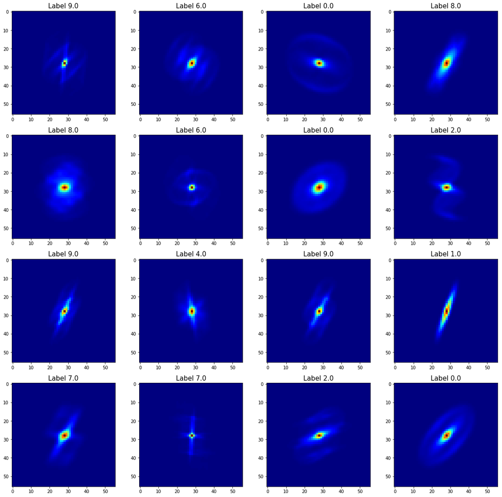

```python
import random
plt.figure(figsize=(20,20))
for i in range(16):
    plt.subplot(4,4,i+1)
    idx = random.randint(1,60000)
    plt.imshow((X_train[idx].transpose(2, 1, 0)).squeeze(),cmap='jet')
    plt.title('Label '+ str(y_train[idx]),fontsize = 15)
```

It can be seen from the representative autocorrelation images that, the autocorrelations have very unique features compared to normal images. These autocorrelation images are rich in features and the CNN would be an ideal way to extract these features and classify the images.

```python
# and one hot encoding the output values
#y_train = y_train[0:NUM_TRAIN_IMAGES]

y_train_ohe = keras.utils.to_categorical(y_train, NUM_CLASSES)
y_test_ohe = keras.utils.to_categorical(y_test, NUM_CLASSES)
print(y_train_ohe.shape)
print(y_test_ohe.shape)
```

```
(60000, 10)
(10000, 10)
```

```python
from sklearn.metrics import roc_curve
from sklearn.metrics import auc
from sklearn.preprocessing import label_binarize

def summarize_net(net, X_test, y_test, title_text=''):
    plt.figure(figsize=(15,5))
    yhat = np.argmax(net.predict(X_test), axis=1)
    acc = mt.accuracy_score(y_test,yhat)
    cm = mt.confusion_matrix(y_test,yhat)
    cm = cm/np.sum(cm,axis=1)[:,np.newaxis].astype(np.float16)
    sns.heatmap(cm, annot=True, fmt='.2f')
    plt.title(title_text+'{:.4f}'.format(acc))
```

# 2. Convolutional Neural Network

A CNN is implemented in this section using Keras. The CNN model follows the standard CNN used in the cnn-demo used in class. It has two convolutional layers with 32 channels (filters to learn) and 64 channels respectively followed by a fully connected layer with softmax activation to generate the 10-dimensional output determining the class to which the autocorelation belongs.

We ran this on the entire training set on a GPU for 20 epochs. We have used a batch size of 256 to train the network.

[output not shown]

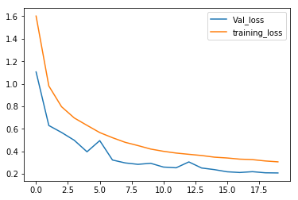

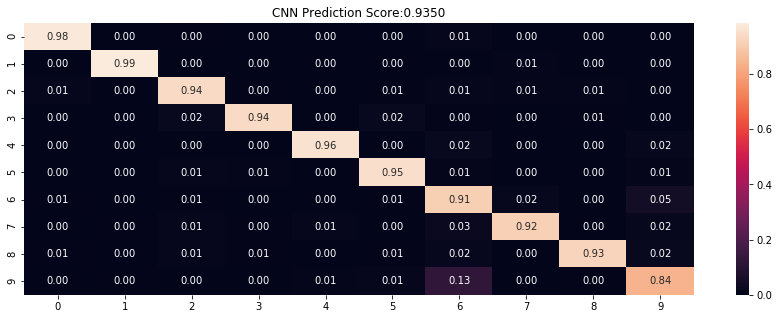

```python
cnn = Sequential()

# let's start with an AlexNet style convolutional phase
cnn.add(Conv2D(filters=32,
                input_shape = (img_wh,img_wh,1),
                kernel_size=(3,3),
                padding='same',
                activation='relu', data_format="channels_last")) # more compact syntax

# no max pool before next conv layer!!
cnn.add(Conv2D(filters=64,
                kernel_size=(3,3),
                padding='same',
                activation='relu')) # more compact syntax
cnn.add(MaxPooling2D(pool_size=(2, 2), data_format="channels_last"))


# add one layer on flattened output
cnn.add(Dropout(0.25)) # add some dropout for regularization after conv layers
cnn.add(Flatten())
cnn.add(Dense(128, activation='relu'))
cnn.add(Dropout(0.5)) # add some dropout for regularization, again!
cnn.add(Dense(NUM_CLASSES, activation='softmax'))

# Let's train the model
cnn.compile(loss='categorical_crossentropy', # 'categorical_crossentropy' 'mean_squared_error'
              optimizer='rmsprop', # 'adadelta' 'rmsprop'
              metrics=['accuracy'])


history = cnn.fit(X_train, y_train_ohe,
                  batch_size=256, epochs=20,
                  shuffle=True, verbose=1,
                  validation_data=(X_test,y_test_ohe))

plt.plot(history.history['val_loss'], label="Val_loss")
plt.plot(history.history['loss'], label="training_loss")
plt.legend()

summarize_net(cnn, X_test, y_test, title_text='CNN Prediction Score:')
```

We could have run it for more epoch as the training and validation losses are still converging but we stopped earlier in the interest of time.

We obtained an accuracy of 93.5% from this CNN model which we believe is very impressive. The confusion matrix is pretty good for the given task with most of the classifications beign close to 90%.

One interesting confusion to note from this confusion matrix is the confusion between 6, 9. As the autocorrelation is a symmetric function, the autocorrelation of 6 and 9 would be almost identical. Hence, the network will have trouble trying to differentiate between these two classes. And this can be easily observed from the confusion matrix as well. Despite this, the network could achieve >80% accuracy with just two convolutional layers is remarkable.

A point to be noted here is that, although we know this issue exists, these confusions are not accepatble for us and hence went for the accuracy metric.

We have added two more convolutional layers (32 and 64 filters each) to the existing network to see if the accuracy improves. As the number of layers increase, we expect the network to learn more complicated features and do much better.

```
Train on 60000 samples, validate on 10000 samples
```

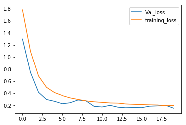

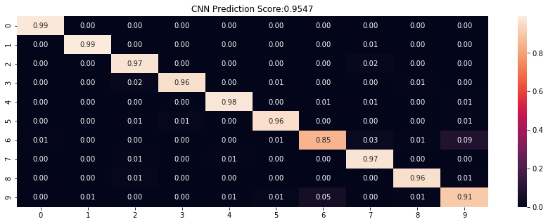

```python
cnn = Sequential()

# let's start with an AlexNet style convolutional phase
cnn.add(Conv2D(filters=32,
                input_shape = (img_wh,img_wh,1),
                kernel_size=(3,3),
                padding='same',
                activation='relu', data_format="channels_last")) # more compact syntax

cnn.add(Conv2D(filters=32,
                input_shape = (img_wh,img_wh,1),
                kernel_size=(3,3),
                padding='same',
                activation='relu', data_format="channels_last")) # more compact syntax

# no max pool before next conv layer!!
cnn.add(Conv2D(filters=64,
                kernel_size=(3,3),
                padding='same',
                activation='relu')) # more compact syntax

cnn.add(Conv2D(filters=64,
                kernel_size=(3,3),
                padding='same',
                activation='relu')) # more compact syntax

cnn.add(MaxPooling2D(pool_size=(2, 2), data_format="channels_last"))


# add one layer on flattened output
cnn.add(Dropout(0.25)) # add some dropout for regularization after conv layers
cnn.add(Flatten())
cnn.add(Dense(128, activation='relu'))
cnn.add(Dropout(0.5)) # add some dropout for regularization, again!
cnn.add(Dense(NUM_CLASSES, activation='softmax'))

# Let's train the model
cnn.compile(loss='categorical_crossentropy', # 'categorical_crossentropy' 'mean_squared_error'
              optimizer='rmsprop', # 'adadelta' 'rmsprop'
              metrics=['accuracy'])


history = cnn.fit(X_train, y_train_ohe,
                  batch_size=256, epochs=20,
                  shuffle=True, verbose=1,
                  validation_data=(X_test,y_test_ohe))

plt.plot(history.history['val_loss'], label="Val_loss")
plt.plot(history.history['loss'], label="training_loss")
plt.legend()

summarize_net(cnn, X_test, y_test, title_text='CNN Prediction Score:')
```

And, as expected, the addition of more layers improved the accuracy to 95.5%. The only class that is performing prrorly is class -6 due to it being mis-classified as 9. Apart from this, all the classes have >90% accuracy and some close to 99% accuracy.

# 3. ResNet

A ResNet is implemented in this section using Keras. This model also follows the cnn-demo used in class. It has five convolutional layers followed by two fully connected layer with softmax activation to generate the 10-dimensional output determining the class to which the autocorelation belongs.

We ran this on the entire training set on a GPU for 20 epochs. We have used a batch size of 256 to train the network.

We have used data expansion in this model to generate additional data to help train the network better.

```python
%%time
try:
    print("started model load")
    with open('model.json', 'r') as file:
        loaded_model_json = file.read()
    resnet = model_from_json(loaded_model_json)
    # load weights into new model
    resnet.load_weights("model.h5")
    resnet.summary()
except Exception as e:
# now lets use the LeNet architecture with batch norm
# We will also use ReLU where approriate and drop out
    from keras.layers.normalization import BatchNormalization
    from keras.layers import Add
    from keras.layers import average, concatenate
    from keras.models import Input, Model
    from keras.regularizers import l2
    l2_lambda = 0.0001

    input_holder = Input(shape=(img_wh, img_wh, 1))

    # start with a conv layer
    x = Conv2D(filters=32,
                   input_shape = (img_wh,img_wh,1),
                   kernel_size=(3,3),
                   kernel_initializer='he_uniform',
                   kernel_regularizer=l2(l2_lambda),
                   padding='same',
                   activation='relu',
                   data_format="channels_last")(input_holder)

    x = MaxPooling2D(pool_size=(2, 2), data_format="channels_last")(x)

    x = Conv2D(filters=32,
                   kernel_size=(3,3),
                   kernel_initializer='he_uniform',
                   kernel_regularizer=l2(l2_lambda),
                   padding='same',
                   activation='relu',
                   data_format="channels_last")(x)

    x_split = MaxPooling2D(pool_size=(2, 2), data_format="channels_last")(x)

    x = Conv2D(filters=64,
                   kernel_size=(1,1),
                   kernel_initializer='he_uniform',
                   kernel_regularizer=l2(l2_lambda),
                   padding='same',
                   activation='relu',
                   data_format="channels_last")(x_split)

    x = Conv2D(filters=64,
                   kernel_size=(3,3),
                   kernel_initializer='he_uniform',
                   kernel_regularizer=l2(l2_lambda),
                   padding='same',
                   activation='relu',
                   data_format="channels_last")(x)

    x = Conv2D(filters=32,
                   kernel_size=(1,1),
                   kernel_initializer='he_uniform',
                   kernel_regularizer=l2(l2_lambda),
                   padding='same',
                   activation='relu',
                   data_format="channels_last")(x)

    # now add back in the split layer, x_split (residual added in)
    x = Add()([x, x_split])
    x = Activation("relu")(x)

    x = MaxPooling2D(pool_size=(2, 2), data_format="channels_last")(x)

    x = Flatten()(x)
    x = Dropout(0.25)(x)
    x = Dense(256)(x)
    x = Activation("relu")(x)
    x = Dropout(0.5)(x)
    x = Dense(NUM_CLASSES)(x)
    x = Activation('softmax')(x)

    resnet = Model(inputs=input_holder,outputs=x)

    resnet.summary()
```

```
started model load
__________________________________________________________________________________________________
Layer (type)                    Output Shape         Param #     Connected to
==================================================================================================
input_1 (InputLayer)            (None, 56, 56, 1)    0
__________________________________________________________________________________________________
conv2d_7 (Conv2D)               (None, 56, 56, 32)   320         input_1[0][0]
__________________________________________________________________________________________________
max_pooling2d_3 (MaxPooling2D)  (None, 28, 28, 32)   0           conv2d_7[0][0]
__________________________________________________________________________________________________
conv2d_8 (Conv2D)               (None, 28, 28, 32)   9248        max_pooling2d_3[0][0]
__________________________________________________________________________________________________
max_pooling2d_4 (MaxPooling2D)  (None, 14, 14, 32)   0           conv2d_8[0][0]
__________________________________________________________________________________________________
conv2d_9 (Conv2D)               (None, 14, 14, 64)   2112        max_pooling2d_4[0][0]
__________________________________________________________________________________________________
conv2d_10 (Conv2D)              (None, 14, 14, 64)   36928       conv2d_9[0][0]
__________________________________________________________________________________________________
conv2d_11 (Conv2D)              (None, 14, 14, 32)   2080        conv2d_10[0][0]
__________________________________________________________________________________________________
add_1 (Add)                     (None, 14, 14, 32)   0           conv2d_11[0][0]
                                                                 max_pooling2d_4[0][0]
__________________________________________________________________________________________________
activation_1 (Activation)       (None, 14, 14, 32)   0           add_1[0][0]
__________________________________________________________________________________________________
max_pooling2d_5 (MaxPooling2D)  (None, 7, 7, 32)     0           activation_1[0][0]
__________________________________________________________________________________________________
flatten_3 (Flatten)             (None, 1568)         0           max_pooling2d_5[0][0]
__________________________________________________________________________________________________
dropout_5 (Dropout)             (None, 1568)         0           flatten_3[0][0]
__________________________________________________________________________________________________
dense_5 (Dense)                 (None, 256)          401664      dropout_5[0][0]
__________________________________________________________________________________________________
activation_2 (Activation)       (None, 256)          0           dense_5[0][0]
__________________________________________________________________________________________________
dropout_6 (Dropout)             (None, 256)          0           activation_2[0][0]
__________________________________________________________________________________________________
dense_6 (Dense)                 (None, 10)           2570        dropout_6[0][0]
__________________________________________________________________________________________________
activation_3 (Activation)       (None, 10)           0           dense_6[0][0]
==================================================================================================
Total params: 454,922
Trainable params: 454,922
Non-trainable params: 0
__________________________________________________________________________________________________
CPU times: user 103 ms, sys: 0 ns, total: 103 ms
Wall time: 101 ms
```

```python
datagen = ImageDataGenerator(featurewise_center=False,
    samplewise_center=False,
    featurewise_std_normalization=False,
    samplewise_std_normalization=False,
    zca_whitening=False,
    rotation_range=5, # used, Int. Degree range for random rotations.
    width_shift_range=0.1, # used, Float (fraction of total width). Range for random horizontal shifts.
    height_shift_range=0.1, # used,  Float (fraction of total height). Range for random vertical shifts.
    fill_mode='nearest',
    cval=0.,
    horizontal_flip=True,
    vertical_flip=True,
    rescale=None)

datagen.fit(X_train)
```

```python
resnet.compile(loss='categorical_crossentropy', # 'categorical_crossentropy' 'mean_squared_error'
                optimizer='adam', # 'adadelta' 'rmsprop'
                metrics=['accuracy'])
```

```python
# history = resnet.fit(X_train, y_train_ohe, batch_size=256,
#                       epochs=20, verbose=1,
#                       validation_data=(X_test,y_test_ohe),
#                       callbacks=[EarlyStopping(monitor='val_loss', patience=4)]
#                      )
history = resnet.fit_generator(datagen.flow(X_train, y_train_ohe, batch_size=256),
                   steps_per_epoch=int(len(X_train)/256), # how many generators to go through per epoch
                   epochs=20, verbose=1,
                   validation_data=(X_test,y_test_ohe)
                  )
```

```python
model_json = resnet.to_json()
with open("model.json", 'w+') as json_file:
    json_file.write(model_json)
resnet.save_weights("model.h5")
print("Weights Saved to Disk")
```

```
Weights Saved to Disk
```

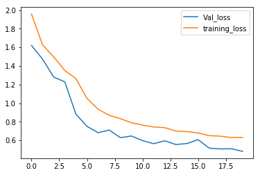

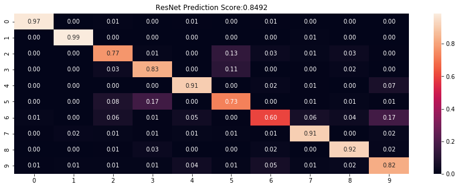

```python
plt.plot(history.history['val_loss'], label="Val_loss")
plt.plot(history.history['loss'], label="training_loss")
plt.legend()

summarize_net(resnet, X_test, y_test, title_text='ResNet Prediction Score:')
```

We could have run it for more epoch as the training and validation losses are still converging but we stopped earlier in the interest of time.

# 4. MLP

Despite the complexity, the MLP performed terribly on the dataset with always classifying the data into class - 1.

We believe this is due to the absence of convolutional layers to extract the features present the autocorrelations. Just a normal MLP is unable to learn the rich features present in the data to classify and ends up always detecting a 1.

```
_________________________________________________________________
Layer (type)                 Output Shape              Param #
=================================================================
input_2 (InputLayer)         (None, 56, 56, 1)         0
_________________________________________________________________
flatten_4 (Flatten)          (None, 3136)              0
_________________________________________________________________
dense_7 (Dense)              (None, 1024)              3212288
_________________________________________________________________
dense_8 (Dense)              (None, 1024)              1049600
_________________________________________________________________
dense_9 (Dense)              (None, 4096)              4198400
_________________________________________________________________
dropout_7 (Dropout)          (None, 4096)              0
_________________________________________________________________
dense_10 (Dense)             (None, 4096)              16781312
_________________________________________________________________
dropout_8 (Dropout)          (None, 4096)              0
_________________________________________________________________
dense_11 (Dense)             (None, 1024)              4195328
_________________________________________________________________
dropout_9 (Dropout)          (None, 1024)              0
_________________________________________________________________
dense_12 (Dense)             (None, 10)                10250
=================================================================
Total params: 29,447,178
Trainable params: 29,447,178
Non-trainable params: 0
_________________________________________________________________
```

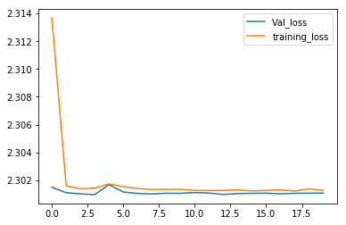

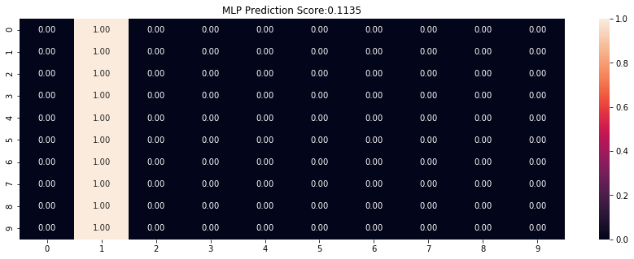

```python
input_holder = Input(shape=(img_wh, img_wh, 1))
x = Flatten()(input_holder)
x = Dense(1024, activation='relu', input_shape=(img_wh, img_wh, 1))(x)
x = Dense(1024, activation='relu', input_shape=(img_wh, img_wh, 1))(x)
x = Dense(4096, activation='relu', input_shape=(img_wh, img_wh, 1))(x)
x = Dropout(0.3)(x)
x = Dense(4096, activation='relu', input_shape=(img_wh, img_wh, 1))(x)
x = Dropout(0.4)(x)
x = Dense(1024, activation='relu', input_shape=(img_wh, img_wh, 1))(x)
x = Dropout(0.5)(x)
x = Dense(10, activation='softmax', input_shape=(img_wh, img_wh, 1))(x)

mlp_model = Model(inputs=input_holder,outputs=x)

mlp_model.summary()

mlp_model.compile(loss='categorical_crossentropy', # 'categorical_crossentropy' 'mean_squared_error'
                optimizer='adam', # 'adadelta' 'rmsprop'
                metrics=['accuracy'])

history = mlp_model.fit_generator(datagen.flow(X_train, y_train_ohe, batch_size=128),
                   steps_per_epoch=int(len(X_train)/128), # how many generators to go through per epoch
                   epochs=20, verbose=1,
                   validation_data=(X_test,y_test_ohe)
                  )

plt.plot(history.history['val_loss'], label="Val_loss")
plt.plot(history.history['loss'], label="training_loss")
plt.legend()

summarize_net(mlp_model, X_test, y_test, title_text='MLP Prediction Score:')
```

# 5. Transfer learning

We have used a ResNet 50 model trained on Imagenet dataset to do transfer learning. The features in autocorrelations are much more different compared to natural images. This would mean that the CNN filters of ResNet 50 may not accurately represent the features in the autocorrelation images.

```python
import keras
from scipy.misc import imresize
from keras.applications.resnet50 import ResNet50
from keras.applications.resnet50 import preprocess_input, decode_predictions

if 'res_model' not in locals():
    res_model = ResNet50(weights='imagenet', include_top=False)
print(X_train.shape)
x_train_stacked = [np.stack((img,)*3, axis=-1) for img in X_train]
x_train_stacked = [np.stack(img.reshape(56,56,3), axis=0) for img in x_train_stacked]
x_train_stacked = np.asarray(x_train_stacked)

x_test_stacked = [np.stack((img,)*3, axis=-1) for img in X_test]
x_test_stacked = [np.stack(img.reshape(56,56,3), axis=0) for img in x_test_stacked]
x_test_stacked = np.asarray(x_test_stacked)

x_train_resnet = res_model.predict(x_train_stacked)
x_test_resnet = res_model.predict(x_test_stacked)

input_x = Input(shape=x_train_resnet[0].shape)
x = Flatten()(input_x)
x = Dense(200, activation='relu', kernel_initializer='he_uniform')(x)
predictions = Dense(10, activation='softmax', kernel_initializer='glorot_uniform')(x)
model = Model(inputs=input_x, outputs=predictions)
model.summary()
```

```
(60000, 56, 56, 1)
_________________________________________________________________
Layer (type)                 Output Shape              Param #
=================================================================
input_4 (InputLayer)         (None, 2, 2, 2048)        0
_________________________________________________________________
flatten_5 (Flatten)          (None, 8192)              0
_________________________________________________________________
dense_13 (Dense)             (None, 200)               1638600
_________________________________________________________________
dense_14 (Dense)             (None, 10)                2010
=================================================================
Total params: 1,640,610
Trainable params: 1,640,610
Non-trainable params: 0
_________________________________________________________________
```

```python
y_train_ohe_resnet = y_train_ohe[:x_train_resnet.shape[0]]

model.compile(optimizer='rmsprop', loss='categorical_crossentropy',metrics=['accuracy'])

history = model.fit(x_train_resnet,y_train_ohe_resnet,epochs=20,
          batch_size=64,verbose=1,
         validation_data=(x_test_resnet, y_test_ohe[:x_test_resnet.shape[0]]))
```

```
Train on 60000 samples, validate on 10000 samples
```

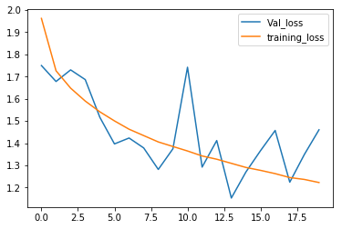

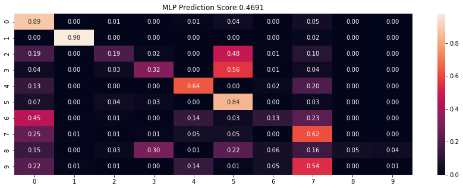

```python
plt.plot(history.history['val_loss'], label="Val_loss")
plt.plot(history.history['loss'], label="training_loss")
plt.legend()

summarize_net(model, x_test_resnet, y_test, title_text='MLP Prediction Score:')
```

Transfer learning approach struggled to converge because the weights of ResNet 50 were optimised for natural images. Since we used autocorrelations, the features extracted by convolutional layers of ResNet couldn't really explain the structures present in autocorrelation images.

We could get only up 46% accuracy. But, looking at the validation loss curve, it alos looks like the networks hasn't settled which could have made the problem even worse.

# Summary

In summary, for this lab, we have explored CNNs and ResNet architectures to classify autocorrelations of digits. CNNs performed exceedingly well on the whole with obtaining 95.5% accuracy within 20 epochs and using 4 convolutional layers. ResNet could get upto 84% within the same time but could have converged had we let it run for a few more epochs. CNNs preformed very well across all classes barring 6 and 9. In hindsight, we think, we could have penalized more for these 6,9 confusions compared to others to make the CNN run better and obtained a much higher accuracy. ResNet had several more such confusions but it most likely would have converged eventually.

MLP was terrible and is as good as a random guess and transfer learning approach struggled to converge because the weights of ResNet 50 were optimised for natural images. Since we used autocorrelations, the features extracted by convolutional layers of ResNet couldn't really explain the structures present in autocorrelation images.

## Appendix

### Matlab code to generate autocorrelations

```python
%%
clc;
close all;
clear all
%%
% Train
% images = loadMNISTImages('train-images.idx3-ubyte');
% labels = loadMNISTLabels('train-labels.idx1-ubyte');
% Test
images = loadMNISTImages('t10k-images.idx3-ubyte');
labels = loadMNISTLabels('t10k-labels.idx1-ubyte');

%%
sz = size(images);
data = zeros(sz(2),56,56);
for i = 1:sz(2)
    i
    temp_label = labels(i,1);
    temp = images(:,i);
    temp = reshape(temp,[28,28]);
    temp = padarray(temp,[14 14],'both');% pad array to so that the autocorrelation is not aliased

    % estimate autocorrelation using FFTs

    temp_propagated = (abs(fftshift(fft2(temp)))).^2;
    backprop = abs(fftshift(fft2(temp_propagated)));
    autocorr = backprop.^2;

    % Normalization
    autocorr = 255*(autocorr - min(autocorr(:)))./(max(autocorr(:)) - min(autocorr(:)));

%     % Write to image
%     str = ['./test/' sprintf('image%d_',i) num2str(temp_label) '.png'];
%     imwrite(autocorr,str)
    data(i,:,:) = uint8(autocorr);
end

matObj = matfile('MNIST_Autocorrelation.mat','Writable', true);
matObj.TestData = data;
matObj.TestLabels = labels;

% matObj.TrainData = data;
% matObj.TrainLabels = labels;
```